# Week6Lab

So in this example, we're going to use buffers and chloropleth maps to visualize truck routes in California.

The first thing we're going to do is download Matplotlib, which extends mapping capacities in Python, and Geopandas, which allows us to handle geospatial data in some cool ways.

```python
%matplotlib inline
import matplotlib
import numpy as np
import matplotlib.pyplot as plt
```

```python
import geopandas as gpd
```

```python
routes_df = gpd.read_file('data/Truck_Route_Network.shp')
```

```python
tracts_df = gpd.read_file('data/clinics.shp')
```

```python
city = gpd.read_file('data/riverside_city.shp')
```

Next, we'll create a city tracts file where we join Riverside geometry to the tracts, so we get the tracts within Riverside.

```python
city_tracts = gpd.sjoin(tracts_df, city, how='inner', op='intersects')
```

Then we'll read in a file of California tracts so we can visualize the whole state.

```python
california_tracts = gpd.read_file('data/california_tracts.shp')
```

Here we'll create a buffer around the truck routes, so we can see a broader area visualized around them.

```python
routes_buffer = routes_df.buffer(.01)
```

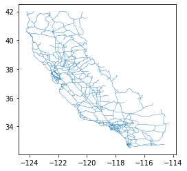

```python
routes_buffer.plot()
```

It's important to change the routes_buffer file so it's a GeoDataFrame, because it was originally a GeoSeries, which is just the geometry of a GeoDataFrame. We'll also change the routes buffer CRS to the California tracts CRS, so that we can join them later.

```python
routes_buffer = gpd.GeoDataFrame({'geometry': routes_buffer})
routes_buffer.crs = california_tracts.crs
```

Next, we'll create ca_intersecting, a file that will bond the CA tracts with the truck routes.

```python
ca_intersecting = gpd.sjoin(california_tracts, routes_buffer, how='inner', op='intersects')
```

We'll plot it with a light blue base color and white buffer, so it's easy to see.

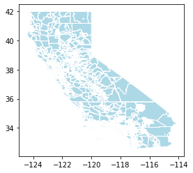

```python
ca_intersecting.plot(edgecolor = 'white', color = 'lightblue')
```

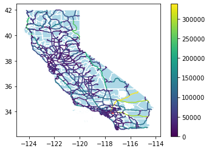

```python
ax = plt.gca()
routes_df.plot(ax=ax, column='seg_length', legend='TRUE')
ca_intersecting.plot(ax=ax, edgecolor = 'white', color = 'lightblue')
city_tracts.plot(ax=ax, color='red')
plt.show()
```